# MoralFoundationsSurvey2

2023-02-20

## Prepare the data

Load separate files for the positive and negative responses

```r
library(readr)

url_neg = "https://raw.githubusercontent.com/NicoleNisbett/Moral-Foundations/main/NEG_coded.csv"
neg_data <- read_csv(url(url_neg))

url_pos = "https://raw.githubusercontent.com/NicoleNisbett/Moral-Foundations/main/POS_coded.csv"
pos_data <- read_csv(url(url_pos))
```

Create the value scales based on TwIVI

```r
create_scales = function(file){
  data = file

  #creating openness to change scales
  subset1 <- data.frame(data$Q3_3,data$Q5_4,data$Q5_3,data$Q4_7)
  data$conformity_val <- rowMeans(subset1)
#Schwartz_5 Schwartz_6 Schwartz_15 Schwartz_16
  subset2 <- data.frame(data$Q5_5,data$Q5_2,data$Q3_4,data$Q4_3)
  data$self_direction_val <- rowMeans(subset2)
  data$SCH_Conservation <- data$conformity_val - data$self_direction_val

  #creating Self-enhancement/Self-trancendencies scales
  subset3 <- data.frame(data$Q3_2,data$Q3_7,data$Q4_4,data$Q5_6)
  data$universalism_val <- rowMeans(subset3)
  #
  subset4 <- data.frame(data$Q3_6,data$Q4_2,data$Q4_5,data$Q5_1)
  data$achievement_val <- rowMeans(subset4)
  data$SCH_SelfTrancendence <- data$universalism_val - data$achievement_val

  return(data)
}

negative = create_scales(neg_data)
negative$sentiment = "negative"

positive = create_scales(pos_data)
positive$sentiment = "positive"
```

## Descriptive Analysis

Rename some of the questions for ease and combine them

```r
names(positive)[names(positive) == "Q17"] <- "Income"
names(negative)[names(negative) == "Q17"] <- "Income"

names(positive)[names(positive) == "Q13"] <- "Age"
names(negative)[names(negative) == "Q13"] <- "Age"

names(positive)[names(positive) == "Q19_1"] <- "Political_Leaning"
names(negative)[names(negative) == "Q19_1"] <- "Political_Leaning"

combined = rbind(negative, positive)
```

Plot the distiribution for income

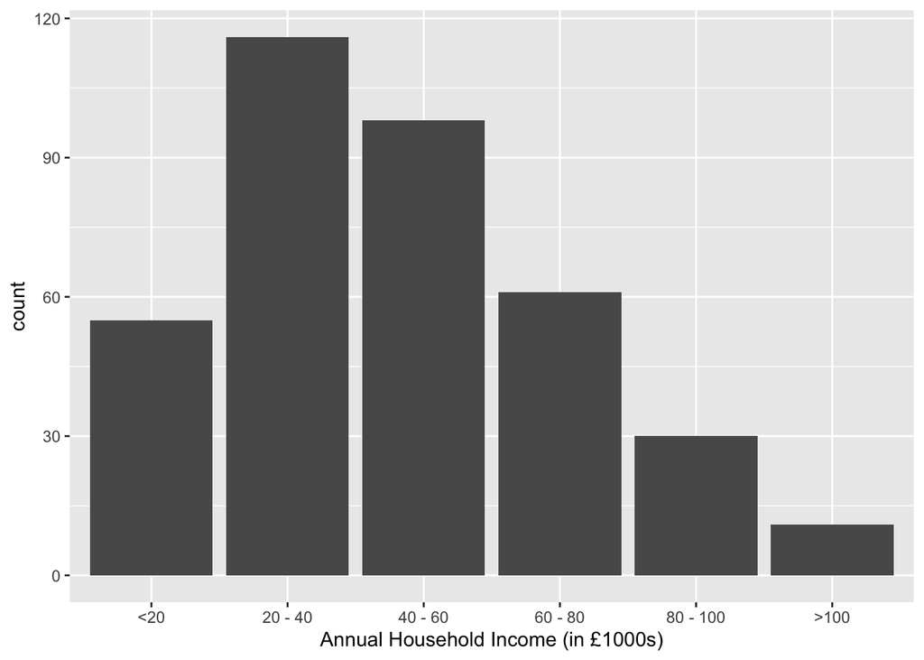

```r
library(ggplot2)
ggplot(combined, aes(x = Income))+ geom_bar() +scale_x_discrete(name = "Annual Household Income (in £1000s)", limits = c("<20", "20 - 40", "40 - 60", "60 - 80", "80 - 100", ">100"))
```

Distribution of educational background

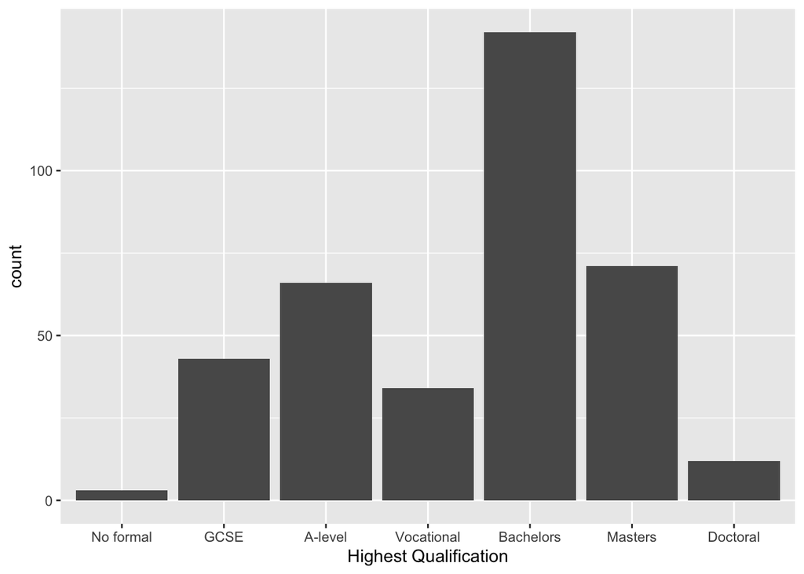

```r
ggplot(combined, aes(x = Q15))+ geom_bar() + scale_x_discrete(name = "Highest Qualification", limits = c("No formal", "GCSE", "A-level", "Vocational", "Bachelors", "Masters", "Doctoral"))
```

Distribution of political leaning

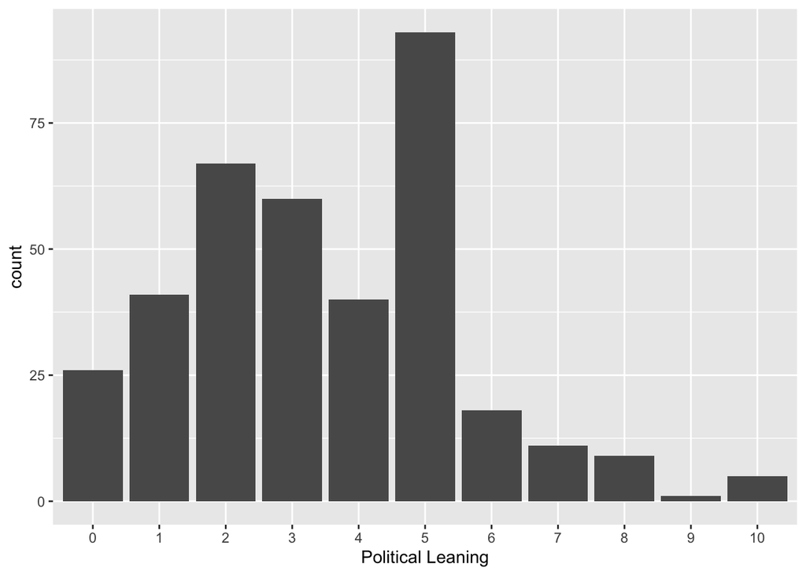

```r
ggplot(combined, aes(x = Political_Leaning))+ geom_bar() + scale_x_discrete(name = "Political Leaning", limits = c("0", "1", "2", "3", "4", "5", "6", "7", "8", "9", "10"))
```

Distribution of self transcendence values

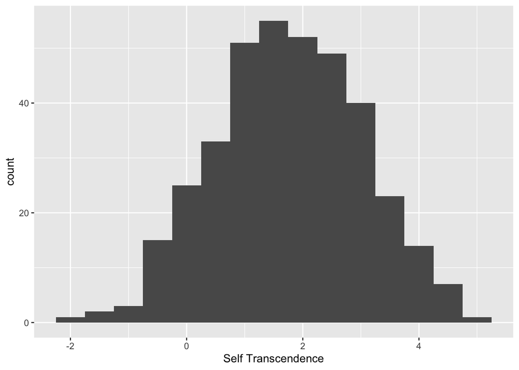

```r
ggplot(combined)+ geom_histogram(mapping = aes(x = SCH_SelfTrancendence), bins = 15) + scale_x_continuous(name = "Self Transcendence")
```

## Confirmatory Factor Analysis (CFA)

```r
library(lavaan)
set.seed(56789)
```

Get just the negative questions

```r
QsN= data.frame(negative$Q6_1_a, negative$Q6_2_a,negative$Q6_3_a,negative$Q6_4_a, negative$Q6_5_a,negative$Q6_6_a, negative$Q7_1_a, negative$Q7_2_a, negative$Q7_3_a, negative$Q7_4_a, negative$Q7_5_a, negative$Q7_6_a , negative$Q8_1_a, negative$Q8_2_a, negative$Q8_3_a, negative$Q8_4_a, negative$Q8_5_a, negative$Q8_6_a)

names(QsN) = c("comp1", "comp2", "comp3", "fair1", "fair2", "fair3", "pur1", "pur2", "pur3", "auth1", "auth2", "auth3", "loy1", "loy2", "loy3", "anc1", "anc2", "anc3")
```

Create the model for the CFA based on all statements and run the model

```r
items = '
compassion =~ comp1 + comp2 + comp3
fairness =~ fair1 + fair2 + fair3
purity =~ pur1 + pur2 + pur3
authority =~ auth1 + auth2 + auth3
loyalty =~ loy1 + loy2 + loy3
ancestors =~ anc1 + anc2 + anc3
'
#decent model but can be improved
cfa_modN = cfa(items, data = QsN)
summary(cfa_modN, standardized = TRUE, fit.measures=TRUE)
```

```
## lavaan 0.6.14 ended normally after 78 iterations
##
##   Estimator                                         ML
##   Optimization method                           NLMINB
##   Number of model parameters                        51
##
##                                                   Used       Total
##   Number of observations                           173         185
##
## Model Test User Model:
##
##   Test statistic                               244.139
##   Degrees of freedom                               120
##   P-value (Chi-square)                           0.000
##
## Model Test Baseline Model:
##
##   Test statistic                              1612.033
##   Degrees of freedom                               153
##   P-value                                        0.000
##
## User Model versus Baseline Model:
##
##   Comparative Fit Index (CFI)                    0.915
##   Tucker-Lewis Index (TLI)                       0.892
##
## Loglikelihood and Information Criteria:
##
##   Loglikelihood user model (H0)              -4575.458
##   Loglikelihood unrestricted model (H1)      -4453.389
##
##   Akaike (AIC)                                9252.917
##   Bayesian (BIC)                              9413.735
##   Sample-size adjusted Bayesian (SABIC)       9252.240
##
## Root Mean Square Error of Approximation:
##
##   RMSEA                                          0.077
##   90 Percent confidence interval - lower         0.063
##   90 Percent confidence interval - upper         0.091
```

[output cut: 74 more lines]

```
##    .auth1             0.862    0.119    7.219    0.000    0.862    0.428
##    .auth2             1.074    0.139    7.740    0.000    1.074    0.496
##    .auth3             0.546    0.082    6.652    0.000    0.546    0.373
##    .loy1              0.845    0.104    8.100    0.000    0.845    0.551
##    .loy2              0.709    0.090    7.858    0.000    0.709    0.508
##    .loy3              0.598    0.092    6.472    0.000    0.598    0.360
##    .anc1              1.072    0.137    7.813    0.000    1.072    0.436
##    .anc2              0.397    0.073    5.417    0.000    0.397    0.232
##    .anc3              0.632    0.086    7.314    0.000    0.632    0.371
##     compassion        0.650    0.158    4.113    0.000    1.000    1.000
##     fairness          0.460    0.182    2.525    0.012    1.000    1.000
##     purity            0.149    0.106    1.406    0.160    1.000    1.000
##     authority         1.153    0.210    5.496    0.000    1.000    1.000
##     loyalty           0.690    0.147    4.693    0.000    1.000    1.000
##     ancestors         1.385    0.249    5.560    0.000    1.000    1.000
```

```r
itemsN = '
compassion =~ comp1 + comp2 + comp3
fairness =~ fair2 + fair3
purity =~ pur2 + pur3
authority =~ auth1 + auth2 + auth3
loyalty =~ loy1 + loy2 + loy3
ancestors =~ anc1 + anc2 + anc3
'
#much better
cfa_modN2 = cfa(itemsN, data = QsN)
summary(cfa_modN2, standardized = TRUE, fit.measures=TRUE)
```

```
## lavaan 0.6.14 ended normally after 55 iterations
##
##   Estimator                                         ML
##   Optimization method                           NLMINB
##   Number of model parameters                        47
##
##                                                   Used       Total
##   Number of observations                           177         185
##
## Model Test User Model:
##
##   Test statistic                               189.012
##   Degrees of freedom                                89
##   P-value (Chi-square)                           0.000
##
## Model Test Baseline Model:
##
##   Test statistic                              1571.247
##   Degrees of freedom                               120
##   P-value                                        0.000
##
## User Model versus Baseline Model:
##
##   Comparative Fit Index (CFI)                    0.931
##   Tucker-Lewis Index (TLI)                       0.907
##
## Loglikelihood and Information Criteria:
##
##   Loglikelihood user model (H0)              -3987.946
##   Loglikelihood unrestricted model (H1)      -3893.440
##
##   Akaike (AIC)                                8069.893
##   Bayesian (BIC)                              8219.172
##   Sample-size adjusted Bayesian (SABIC)       8070.331
##
## Root Mean Square Error of Approximation:
##
##   RMSEA                                          0.080
##   90 Percent confidence interval - lower         0.064
##   90 Percent confidence interval - upper         0.095
```

[output cut: 70 more lines]

```
##    .auth1             0.842    0.116    7.254    0.000    0.842    0.422
##    .auth2             1.061    0.136    7.805    0.000    1.061    0.492
##    .auth3             0.542    0.080    6.742    0.000    0.542    0.374
##    .loy1              0.840    0.102    8.214    0.000    0.840    0.551
##    .loy2              0.696    0.088    7.951    0.000    0.696    0.505
##    .loy3              0.584    0.090    6.501    0.000    0.584    0.354
##    .anc1              1.055    0.133    7.903    0.000    1.055    0.433
##    .anc2              0.387    0.071    5.489    0.000    0.387    0.230
##    .anc3              0.619    0.084    7.398    0.000    0.619    0.367
##     compassion        0.649    0.156    4.167    0.000    1.000    1.000
##     fairness          0.613    0.128    4.809    0.000    1.000    1.000
##     purity            0.873    0.160    5.448    0.000    1.000    1.000
##     authority         1.152    0.206    5.596    0.000    1.000    1.000
##     loyalty           0.683    0.144    4.746    0.000    1.000    1.000
##     ancestors         1.382    0.244    5.654    0.000    1.000    1.000
```

Even better model now those statements have been removed so we can create the indices.

```r
get_neg_morals = function(negative){
  negative$compassion = rowMeans(data.frame(negative$Q6_1_a, negative$Q6_2_a,negative$Q6_3_a), na.rm = TRUE)

  negative$fairness = rowMeans(data.frame(negative$Q6_5_a,negative$Q6_6_a), na.rm = TRUE)

  negative$purity = rowMeans(data.frame(negative$Q7_2_a, negative$Q7_3_a), na.rm = TRUE)

  negative$authority = rowMeans(data.frame(negative$Q7_4_a, negative$Q7_5_a, negative$Q7_6_a), na.rm = TRUE)

  negative$loyalty = rowMeans(data.frame(negative$Q8_1_a, negative$Q8_2_a, negative$Q8_3_a), na.rm = TRUE)

  negative$ancestors = rowMeans(data.frame(negative$Q8_4_a, negative$Q8_5_a, negative$Q8_6_a), na.rm = TRUE)

  return(negative)
}

negative = get_neg_morals(negative)
```

Now repeat the process for positive statements

```r
QsP= data.frame(positive$Q6_1_a, positive$Q6_2_a,positive$Q6_3_a,positive$Q6_4_a, positive$Q6_5_a,positive$Q6_6_a, positive$Q7_1_a, positive$Q7_2_a, positive$Q7_3_a, positive$Q7_4_a, positive$Q7_5_a, positive$Q7_6_a , positive$Q8_1_a, positive$Q8_2_a, positive$Q8_3_a, positive$Q8_4_a, positive$Q8_5_a, positive$Q8_6_a)

names(QsP) = c("comp1", "comp2", "comp3", "fair1", "fair2", "fair3", "pur1", "pur2", "pur3", "auth1", "auth2", "auth3", "loy1", "loy2", "loy3", "anc1", "anc2", "anc3")

items = '
compassion =~ comp1 + comp2 + comp3
fairness =~ fair1 + fair2 + fair3
purity =~ pur1 + pur2 + pur3
authority =~ auth1 + auth2 + auth3
loyalty =~ loy1 + loy2 + loy3
ancestors =~ anc1 + anc2 + anc3
'

#pretty bad model but can also be improved
cfa_modP = cfa(items, data = QsP)
summary(cfa_modP, standardized = TRUE, fit.measures=TRUE)
```

```
## lavaan 0.6.14 ended normally after 70 iterations
##
##   Estimator                                         ML
##   Optimization method                           NLMINB
##   Number of model parameters                        51
##
##                                                   Used       Total
##   Number of observations                           178         186
##
## Model Test User Model:
##
##   Test statistic                               466.401
##   Degrees of freedom                               120
##   P-value (Chi-square)                           0.000
##
## Model Test Baseline Model:
##
##   Test statistic                              1623.999
##   Degrees of freedom                               153
##   P-value                                        0.000
##
## User Model versus Baseline Model:
##
##   Comparative Fit Index (CFI)                    0.765
##   Tucker-Lewis Index (TLI)                       0.700
##
## Loglikelihood and Information Criteria:
##
##   Loglikelihood user model (H0)              -4943.452
##   Loglikelihood unrestricted model (H1)      -4710.252
##
##   Akaike (AIC)                                9988.905
##   Bayesian (BIC)                             10151.176
##   Sample-size adjusted Bayesian (SABIC)       9989.665
##
## Root Mean Square Error of Approximation:
##
##   RMSEA                                          0.127
##   90 Percent confidence interval - lower         0.115
##   90 Percent confidence interval - upper         0.140
```

[output cut: 74 more lines]

```
##    .auth1             1.303    0.157    8.285    0.000    1.303    0.573
##    .auth2             0.676    0.091    7.419    0.000    0.676    0.453
##    .auth3             0.946    0.118    8.041    0.000    0.946    0.531
##    .loy1              1.039    0.122    8.547    0.000    1.039    0.660
##    .loy2              1.459    0.183    7.966    0.000    1.459    0.546
##    .loy3              0.572    0.118    4.832    0.000    0.572    0.285
##    .anc1              1.401    0.176    7.967    0.000    1.401    0.559
##    .anc2              0.465    0.080    5.801    0.000    0.465    0.353
##    .anc3              0.714    0.086    8.305    0.000    0.714    0.619
##     compassion        0.527    0.157    3.357    0.001    1.000    1.000
##     fairness          0.954    0.186    5.123    0.000    1.000    1.000
##     purity            0.694    0.170    4.082    0.000    1.000    1.000
##     authority         0.973    0.212    4.598    0.000    1.000    1.000
##     loyalty           0.534    0.135    3.946    0.000    1.000    1.000
##     ancestors         1.107    0.240    4.618    0.000    1.000    1.000
```

Remove the statements with low loadings and run again

```r
#remove comp1, pur2, loy1, fair3
itemsP = '
compassion =~ comp2 + comp3
fairness =~ fair1 + fair2
purity =~ pur1 + pur3
authority =~ auth1 + auth2 + auth3
loyalty =~ loy2 + loy3
ancestors =~ anc1 + anc2 + anc3
'
#a bit better but still under the thresholds
cfa_modP2 = cfa(itemsP, data = QsP)
summary(cfa_modP2, standardized = TRUE, fit.measures=TRUE)
```

```
## lavaan 0.6.14 ended normally after 57 iterations
##
##   Estimator                                         ML
##   Optimization method                           NLMINB
##   Number of model parameters                        43
##
##                                                   Used       Total
##   Number of observations                           179         186
##
## Model Test User Model:
##
##   Test statistic                               212.545
##   Degrees of freedom                                62
##   P-value (Chi-square)                           0.000
##
## Model Test Baseline Model:
##
##   Test statistic                              1253.194
##   Degrees of freedom                                91
##   P-value                                        0.000
##
## User Model versus Baseline Model:
##
##   Comparative Fit Index (CFI)                    0.870
##   Tucker-Lewis Index (TLI)                       0.810
##
## Loglikelihood and Information Criteria:
##
##   Loglikelihood user model (H0)              -3752.166
##   Loglikelihood unrestricted model (H1)      -3645.893
##
##   Akaike (AIC)                                7590.332
##   Bayesian (BIC)                              7727.389
##   Sample-size adjusted Bayesian (SABIC)       7591.211
##
## Root Mean Square Error of Approximation:
##
##   RMSEA                                          0.116
##   90 Percent confidence interval - lower         0.100
##   90 Percent confidence interval - upper         0.134
```

[output cut: 66 more lines]

```
##    .pur3              0.537    0.096    5.570    0.000    0.537    0.455
##    .auth1             1.283    0.156    8.208    0.000    1.283    0.555
##    .auth2             0.645    0.091    7.104    0.000    0.645    0.417
##    .auth3             0.965    0.120    8.035    0.000    0.965    0.526
##    .loy2              1.501    0.189    7.933    0.000    1.501    0.560
##    .loy3              0.237    0.160    1.480    0.139    0.237    0.116
##    .anc1              1.438    0.177    8.133    0.000    1.438    0.575
##    .anc2              0.450    0.081    5.535    0.000    0.450    0.332
##    .anc3              0.736    0.087    8.466    0.000    0.736    0.641
##     compassion        1.359    0.217    6.271    0.000    1.000    1.000
##     fairness          1.117    0.205    5.447    0.000    1.000    1.000
##     purity            0.644    0.164    3.940    0.000    1.000    1.000
##     authority         1.029    0.218    4.727    0.000    1.000    1.000
##     loyalty           1.181    0.257    4.603    0.000    1.000    1.000
##     ancestors         1.063    0.234    4.536    0.000    1.000    1.000
```

The positive model is still under the recommended thresholds so these indices do not work for the positive statements. Instead of indices we’ll just use the most convincing statement from each moral category.

```r
names(positive)[names(positive) == "Q6_2_a"] <- "CP2"
names(positive)[names(positive) == "Q6_5_a"] <- "FP2"
names(positive)[names(positive) == "Q7_3_a"] <- "PP3"
names(positive)[names(positive) == "Q7_6_a"] <- "AP3"
names(positive)[names(positive) == "Q8_1_a"] <- "LP1"
names(positive)[names(positive) == "Q8_6_a"] <- "GAP3"
```

## Measuring convincingness ratings

Most convincing among the negative indices

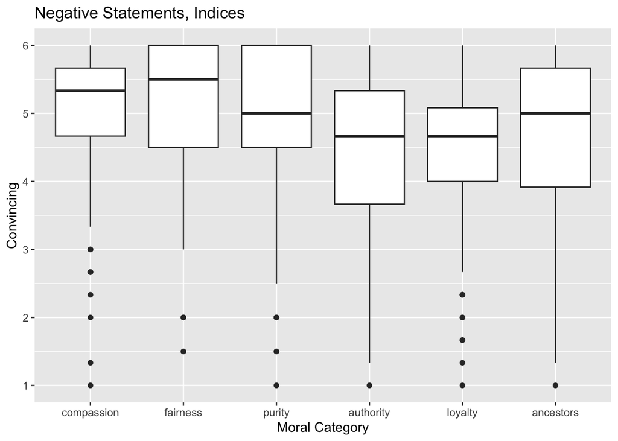

```r
library(reshape2)
library(ggplot2)
neg_melt = melt(negative, measure.vars = c("compassion", "fairness", "purity", "authority", "loyalty", "ancestors"), na.rm=TRUE)
ggplot(neg_melt, aes(x = variable, y = value)) + geom_boxplot() + ggtitle("Negative Statements, Indices") + xlab("Moral Category") + ylab("Convincing") + scale_y_continuous(breaks = c(1,2,3,4,5,6))
```

And the same for mot convincing positive statements

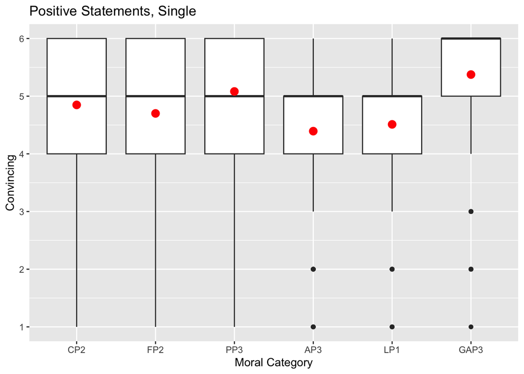

```r
pos_melt = melt(positive, measure.vars = c("CP2", "FP2", "PP3", "AP3", "LP1", "GAP3"), na.rm=TRUE)
ggplot(pos_melt, aes(x = variable, y = value)) +
  geom_boxplot() +stat_summary(fun.y=mean, geom="point", shape=20, size=5, color="red", fill="red") +
  ggtitle("Positive Statements, Single") + xlab("Moral Category") + ylab("Convincing") +
  scale_y_continuous(breaks = c(1,2,3,4,5,6))
```

Recode the applicability and novelty questions so they are 0 and 1.

```r
applicableN = data.frame(negative$Q6_1_b, negative$Q6_2_b,negative$Q6_3_b,negative$Q6_4_b, negative$Q6_5_b,negative$Q6_6_b, negative$Q7_1_b, negative$Q7_2_b, negative$Q7_3_b, negative$Q7_4_b, negative$Q7_5_b, negative$Q7_6_b , negative$Q8_1_b, negative$Q8_2_b, negative$Q8_3_b, negative$Q8_4_b, negative$Q8_5_b, negative$Q8_6_b)
applicableN[applicableN == 2] <- 0 #not applicable
applicableN[applicableN == 1] <- 1 #applicable


applicableP = data.frame(positive$Q6_1_b, positive$Q6_2_b,positive$Q6_3_b,positive$Q6_4_b, positive$Q6_5_b,positive$Q6_6_b, positive$Q7_1_b, positive$Q7_2_b, positive$Q7_3_b, positive$Q7_4_b, positive$Q7_5_b, positive$Q7_6_b , positive$Q8_1_b, positive$Q8_2_b, positive$Q8_3_b, positive$Q8_4_b, positive$Q8_5_b, positive$Q8_6_b)
applicableP[applicableP == 2] <- 0 #not applicable
applicableP[applicableP == 1] <- 1 #applicable


##Novel (closer to 2 = more novel)
novelsN = negative[, 66:85]
novelsN = novelsN[, -c(7,14)]

novelsN[novelsN == 1] <- 0 #not novel
novelsN[novelsN == 2] <- 1 #novel
novelsN = data.frame(novelsN)


novelsP = positive[ , 66:85]
novelsP = novelsP[ , -c(7,14)]

novelsP[novelsP == 1] <- 0 #not novel
novelsP[novelsP == 2] <- 1 #novel
```

Compare different moral foundations to each other using a paired t-test for the negative indices.

```r
library(lsr)
cf = t.test(negative$compassion, negative$fairness, paired = TRUE)
round(cohensD(negative$compassion, negative$fairness),2)
```

```
## [1] 0.03
```

```r
cp = t.test(negative$compassion, negative$purity, paired = TRUE)
round(cohensD(negative$compassion, negative$purity),2)
```

```
## [1] 0.17
```

```r
ca = t.test(negative$compassion, negative$authority, paired = TRUE)
round(cohensD(negative$compassion, negative$authority),2)
```

```
## [1] 0.6
```

```r
cl = t.test(negative$compassion, negative$loyalty, paired = TRUE)
round(cohensD(negative$compassion, negative$loyalty),2)
```

```
## [1] 0.61
```

```r
can = t.test(negative$compassion, negative$ancestors, paired = TRUE)
round(cohensD(negative$compassion, negative$ancestors),2)
```

```
## [1] 0.36
```

```r
fp = t.test(negative$fairness, negative$purity, paired = TRUE)
round(cohensD(negative$fairness, negative$purity),2)
```

```
## [1] 0.19
```

```r
fa = t.test(negative$fairness, negative$authority, paired = TRUE)
round(cohensD(negative$fairness, negative$authority),2)
```

```
## [1] 0.6
```

```r
fl = t.test(negative$fairness, negative$loyalty, paired = TRUE)
round(cohensD(negative$fairness, negative$loyalty),2)
```

```
## [1] 0.61
```

```r
fan = t.test(negative$fairness, negative$ancestors, paired = TRUE)
round(cohensD(negative$fairness, negative$ancestors),2)
```

```
## [1] 0.37
```

```r
pa = t.test(negative$purity, negative$authority, paired = TRUE)
round(cohensD(negative$purity, negative$authority),2)
```

```
## [1] 0.42
```

```r
pl = t.test(negative$purity, negative$loyalty, paired = TRUE)
round(cohensD(negative$purity, negative$loyalty),2)
```

```
## [1] 0.42
```

```r
pan = t.test(negative$purity, negative$ancestors, paired = TRUE)
round(cohensD(negative$purity, negative$ancestors),2)
```

```
## [1] 0.19
```

```r
al = t.test(negative$authority, negative$loyalty, paired = TRUE)
round(cohensD(negative$authority, negative$loyalty),2)
```

```
## [1] 0.03
```

```r
aan = t.test(negative$authority, negative$ancestors, paired = TRUE)
round(cohensD(negative$authority, negative$ancestors),2)
```

```
## [1] 0.21
```

```r
lan = t.test(negative$loyalty, negative$ancestors, paired = TRUE)
round(cohensD(negative$loyalty, negative$ancestors),2)
```

```
## [1] 0.19
```

Table below shows only fairness and compassion, authority and loyalty are statistically insignificant, all others have statistically different means.

```r
ncomp = c("x",round(cf$statistic, 2), round(cp$statistic, 2), round(ca$statistic, 2), round(cl$statistic, 2), round(can$statistic, 2))
nfai = c("x", "x", round(fp$statistic, 2), round(fa$statistic, 2), round(fl$statistic, 2), round(fan$statistic, 2))

npur = c("x", "x", "x", round(pa$statistic, 2), round(pl$statistic, 2), round(pan$statistic, 2))

nauth = c("x", "x", "x", "x", round(al$statistic, 2), round(aan$statistic, 2))

nloy = c("x", "x", "x", "x", "x", round(lan$statistic, 2))

nanc = c("x", "x", "x", "x","x", "x")

data.frame(ncomp, nfai, npur, nauth, nloy, nanc, row.names = c("compassion", "fairness", "purity", "authority", "loyalty", "ancestors"))
```

```
##            ncomp nfai npur nauth  nloy nanc
## compassion     x    x    x     x     x    x
## fairness    -0.4    x    x     x     x    x
## purity      2.63 2.51    x     x     x    x
## authority   8.42  8.4 6.36     x     x    x
## loyalty     8.73 8.14  6.2 -0.42     x    x
## ancestors    5.2 5.32 2.91 -2.98 -3.07    x
```

For positive statements use the paired Wilcoxon test to compare moral foundation convincingness scores

```r
pcf = wilcox.test(positive$CP2, positive$FP2, paired = TRUE)
round(cohensD(positive$CP2, positive$FP2),2)
```

```
## [1] 0.11
```

```r
pcp = wilcox.test(positive$CP2, positive$PP3, paired = TRUE)
round(cohensD(positive$CP2, positive$PP3),2)
```

```
## [1] 0.19
```

```r
pca = wilcox.test(positive$CP2, positive$AP3, paired = TRUE)
round(cohensD(positive$CP2, positive$AP3),2)
```

```
## [1] 0.33
```

```r
pcl = wilcox.test(positive$CP2, positive$LP1, paired = TRUE)
round(cohensD(positive$CP2, positive$LP1),2)
```

```
## [1] 0.25
```

```r
pcan = wilcox.test(positive$CP2, positive$GAP3, paired = TRUE)
round(cohensD(positive$CP2, positive$GAP3),2)
```

```
## [1] 0.43
```

```r
pfp = wilcox.test(positive$FP2, positive$PP3, paired = TRUE)
round(cohensD(positive$FP2, positive$PP3),2)
```

```
## [1] 0.31
```

```r
pfa = wilcox.test(positive$FP2, positive$AP3, paired = TRUE)
round(cohensD(positive$FP2, positive$AP3),2)
```

```
## [1] 0.23
```

```r
pfl = wilcox.test(positive$FP2, positive$LP1, paired = TRUE)
round(cohensD(positive$FP2, positive$LP1),2)
```

```
## [1] 0.14
```

```r
pfan = wilcox.test(positive$FP2, positive$GAP3, paired = TRUE)
round(cohensD(positive$FP2, positive$GAP3),2)
```

```
## [1] 0.55
```

```r
ppa = wilcox.test(positive$PP3, positive$AP3, paired = TRUE)
round(cohensD(positive$PP3, positive$AP3),2)
```

```
## [1] 0.56
```

```r
ppl = wilcox.test(positive$PP3, positive$LP1, paired = TRUE)
round(cohensD(positive$PP3, positive$LP1),2)
```

```
## [1] 0.48
```

```r
ppan = wilcox.test(positive$PP3, positive$GAP3, paired = TRUE)
round(cohensD(positive$PP3, positive$GAP3),2)
```

```
## [1] 0.27
```

```r
pal = wilcox.test(positive$AP3, positive$LP1, paired = TRUE)
round(cohensD(positive$AP3, positive$LP1),2)
```

```
## [1] 0.09
```

```r
paan = wilcox.test(positive$AP3, positive$GAP3, paired = TRUE)
round(cohensD(positive$AP3, positive$GAP3),2)
```

```
## [1] 0.81
```

```r
plan = wilcox.test(positive$LP1, positive$GAP3, paired = TRUE)
round(cohensD(positive$LP1, positive$GAP3),2)
```

```
## [1] 0.73
```

Only compassion and fairness/purity, authority and loyalty are statistically insignificant.

```r
pcomp = c("x",round(pcf$statistic, 2), round(pcp$statistic, 2), round(pca$statistic, 2), round(pcl$statistic, 2), round(pcan$statistic, 2))
pfai = c("x", "x", round(pfp$statistic, 2), round(pfa$statistic, 2), round(pfl$statistic, 2), round(pfan$statistic, 2))

ppur = c("x", "x", "x", round(ppa$statistic, 2), round(ppl$statistic, 2), round(ppan$statistic, 2))

pauth = c("x", "x", "x", "x", round(pal$statistic, 2), round(paan$statistic, 2))

ploy = c("x", "x", "x", "x", "x", round(plan$statistic, 2))

panc = c("x", "x", "x", "x","x", "x")

data.frame(pcomp, pfai, ppur, pauth, ploy, panc, row.names = c("CP2", "FP2", "PP3", "AP3", "LP1", "GAP3"))
```

```
##       pcomp   pfai   ppur pauth ploy panc
## CP2       x      x      x     x    x    x
## FP2    2858      x      x     x    x    x
## PP3    2499   1546      x     x    x    x
## AP3    4617   4196 4879.5     x    x    x
## LP1  4744.5 4161.5   4523  3095    x    x
## GAP3   1110 1294.5 1600.5   824 1178    x
```

## Correlations

Calculate correlations between convincingness ratings and applicability, and convincingness ratings and novelty

```r
pBiserialcorrs = function(x,y){
  corlist = list()
  for(i in 1:18){
    check = cor.test(as.numeric(unlist(x[,i])), y[,i], alternative = "t")

    corlist = append(corlist, c(check$statistic, round(check$p.value, 4),round(check$estimate, 2)))
  }

  corframe = data.frame(matrix(unlist(corlist), nrow = 18, byrow = TRUE))
  colnames(corframe) = c("t-statistic", "p-value", "correlation")
  corframe$statement = colnames(y)
  return(corframe)
}
```

Convincingness and novelty

```r
#
novelsQsN = pBiserialcorrs(novelsN, QsN)
summary(novelsQsN$correlation)
```

```
##    Min. 1st Qu.  Median    Mean 3rd Qu.    Max.
## -0.3800 -0.3125 -0.2750 -0.2733 -0.2375 -0.1400
```

```r
novelsQsP = pBiserialcorrs(novelsP, QsP)
summary(novelsQsP$correlation)
```

```
##    Min. 1st Qu.  Median    Mean 3rd Qu.    Max.
## -0.3900 -0.2975 -0.2550 -0.2539 -0.2100 -0.0700
```

Convincingness and applicability

```r
applicableQsN = pBiserialcorrs(applicableN, QsN)
summary(applicableQsN$correlation)
```

```
##    Min. 1st Qu.  Median    Mean 3rd Qu.    Max.
##  0.2400  0.4175  0.4750  0.4711  0.5300  0.6100
```

```r
applicableQsP = pBiserialcorrs(applicableP, QsP)
summary(applicableQsP$correlation)
```

```
##    Min. 1st Qu.  Median    Mean 3rd Qu.    Max.
##  0.3200  0.4125  0.4600  0.4761  0.5650  0.6400
```

Novelty and applicability

```r
corrs = function(x,y){
  corlist = list()
  for(i in 1:18){
    check = cor(x[i], y[i], use = "complete.obs")

    corlist = append(corlist, round(check[1], 2))
  }

  corframe = data.frame(matrix(unlist(corlist), nrow = 18, byrow = TRUE))
  colnames(corframe) = c("correlation")
  corframe$statement = c("comp1", "comp2", "comp3", "fair1", "fair2", "fair3", "pur1", "pur2", "pur3", "auth1", "auth2", "auth3", "loy1", "loy2", "loy3", "anc1", "anc2", "anc3")
  return(corframe)
}
```

```r
applicableNovelsN = corrs(applicableN, novelsN)
summary(applicableNovelsN$correlation)
```

```
##    Min. 1st Qu.  Median    Mean 3rd Qu.    Max.
## -0.4600 -0.2600 -0.2100 -0.2161 -0.1525 -0.0800
```

```r
applicableNovelsP = corrs(applicableP, novelsP)
summary(applicableNovelsP$correlation)
```

```
##    Min. 1st Qu.  Median    Mean 3rd Qu.    Max.
## -0.3500 -0.3200 -0.2200 -0.2339 -0.1825 -0.0800
```

Calculate correlations between values and morals

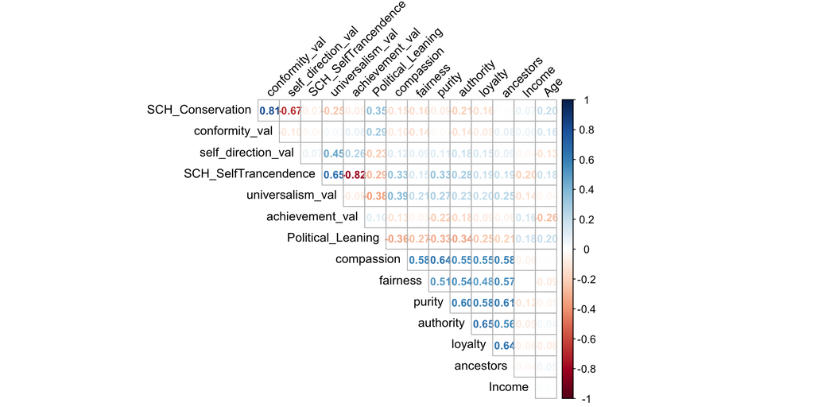

```r
library(psych)
library(corrplot)

correlations_neg = cor(negative[, c("SCH_Conservation","conformity_val", "self_direction_val", "SCH_SelfTrancendence", "universalism_val", "achievement_val", "Political_Leaning", "compassion", "fairness", "purity", "authority", "loyalty", "ancestors", "Income", "Age" )], use = "complete.obs")

corrplot(round(correlations_neg, 2), type = "upper",order = "original",
         tl.col = "black", tl.srt = 45, method = "number", diag = FALSE, number.cex = 0.8, tl.cex = 0.9, cl.cex = 0.8)
```

Repeat for positive statements

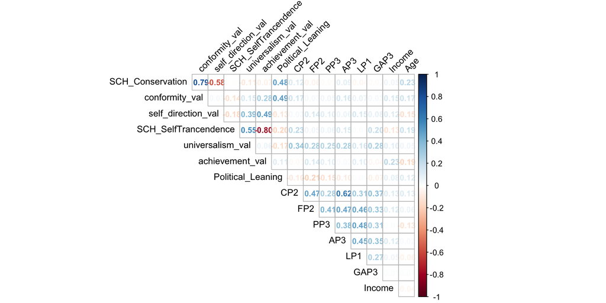

```r
correlations_pos = cor(positive[, c("SCH_Conservation","conformity_val", "self_direction_val", "SCH_SelfTrancendence", "universalism_val", "achievement_val", "Political_Leaning", "CP2", "FP2", "PP3", "AP3", "LP1", "GAP3", "Income", "Age" )], use = "complete.obs")

corrplot(round(correlations_pos, 2), type = "upper",order = "original",
         tl.col = "black", tl.srt = 45, method = "number", diag = FALSE, number.cex = 0.8, tl.cex = 0.9, cl.cex = 0.8)
```

## T-tests

Calculate 2-sample t-tests to compare how different demographic groups were convinced by statements

Political leaning

```r
library(dplyr)
library(lsr)
negative = negative %>%
  mutate(politics = case_when(Political_Leaning < 5 ~ "Left", Political_Leaning >= 5 ~ "Right") )

table(negative$politics)
```

```
##
##  Left Right
##    96    89
```

```r
leftN = subset(negative, politics == "Left")
rightN = subset(negative, politics == "Right")

t.test(leftN$compassion, rightN$compassion, var.equal = FALSE)
```

```
##
##  Welch Two Sample t-test
##
## data:  leftN$compassion and rightN$compassion
## t = 4.8843, df = 138.29, p-value = 2.827e-06
## alternative hypothesis: true difference in means is not equal to 0
## 95 percent confidence interval:
##  0.3960360 0.9347721
## sample estimates:
## mean of x mean of y
##  5.388889  4.723485
```

```r
cohensD(leftN$compassion, rightN$compassion)
```

```
## [1] 0.7362929
```

```r
t.test(leftN$fairness, rightN$fairness, var.equal = FALSE)
```

```
##
##  Welch Two Sample t-test
##
## data:  leftN$fairness and rightN$fairness
## t = 2.9358, df = 156.83, p-value = 0.003828
## alternative hypothesis: true difference in means is not equal to 0
## 95 percent confidence interval:
##  0.1468654 0.7508619
## sample estimates:
## mean of x mean of y
##  5.312500  4.863636
```

```r
cohensD(leftN$fairness, rightN$fairness)
```

```
## [1] 0.4393254
```

```r
t.test(leftN$purity, rightN$purity, var.equal = FALSE)
```

```
##
##  Welch Two Sample t-test
##
## data:  leftN$purity and rightN$purity
## t = 4.3603, df = 158.8, p-value = 2.326e-05
## alternative hypothesis: true difference in means is not equal to 0
## 95 percent confidence interval:
##  0.3604867 0.9574558
## sample estimates:
## mean of x mean of y
##  5.215789  4.556818
```

```r
cohensD(leftN$purity, rightN$purity)
```

```
## [1] 0.6526163
```

```r
t.test(leftN$authority, rightN$authority, var.equal = FALSE)
```

```
##
##  Welch Two Sample t-test
##
## data:  leftN$authority and rightN$authority
## t = 5.415, df = 151.48, p-value = 2.355e-07
## alternative hypothesis: true difference in means is not equal to 0
## 95 percent confidence interval:
##  0.5500451 1.1820124
## sample estimates:
## mean of x mean of y
##  4.850877  3.984848
```

```r
cohensD(leftN$authority, rightN$authority)
```

```
## [1] 0.8126443
```

```r
t.test(leftN$loyalty, rightN$loyalty, var.equal = FALSE)
```

```
##
##  Welch Two Sample t-test
##
## data:  leftN$loyalty and rightN$loyalty
## t = 4.3601, df = 159.08, p-value = 2.326e-05
## alternative hypothesis: true difference in means is not equal to 0
## 95 percent confidence interval:
##  0.3472491 0.9223216
## sample estimates:
## mean of x mean of y
##  4.767361  4.132576
```

```r
cohensD(leftN$loyalty, rightN$loyalty)
```

```
## [1] 0.6518588
```

```r
t.test(leftN$ancestors, rightN$ancestors, var.equal = FALSE)
```

```
##
##  Welch Two Sample t-test
##
## data:  leftN$ancestors and rightN$ancestors
## t = 3.4416, df = 164.42, p-value = 0.0007332
## alternative hypothesis: true difference in means is not equal to 0
## 95 percent confidence interval:
##  0.2578876 0.9520240
## sample estimates:
## mean of x mean of y
##  4.970486  4.365530
```

```r
cohensD(leftN$ancestors, rightN$ancestors)
```

```
## [1] 0.5133303
```

Signifiant p-values so can visualise in a boxplot

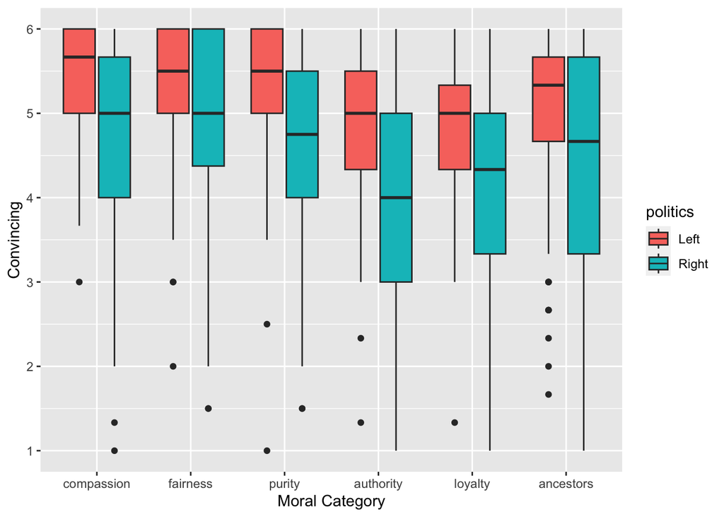

```r
neg_melt = melt(negative, measure.vars = c("compassion", "fairness", "purity", "authority", "loyalty", "ancestors"), na.rm=TRUE)

#Which political leaning of participants are more convinced?
ggplot(neg_melt, aes(x = variable, y = value, fill = politics)) + geom_boxplot() + xlab("Moral Category") + ylab("Convincing") + scale_y_continuous(breaks = c(1,2,3,4,5,6))
```

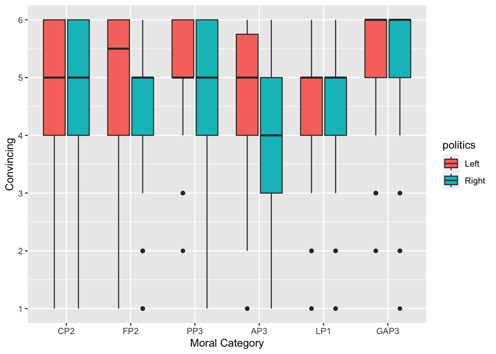

```r
positive = positive %>%
  mutate(politics = case_when(Political_Leaning < 5 ~ "Left", Political_Leaning >= 5 ~ "Right") )

pos_melt = melt(positive, measure.vars = c("CP2", "FP2", "PP3", "AP3", "LP1", "GAP3"), na.rm=TRUE)

#Which political leaning of participants are more convinced?
ggplot(pos_melt, aes(x = variable, y = value, fill = politics)) + geom_boxplot() + xlab("Moral Category") + ylab("Convincing") + scale_y_continuous(breaks = c(1,2,3,4,5,6))
```

```r
table(positive$politics)
```

```
##
##  Left Right
##    98    88
```

```r
leftP = subset(positive, politics == "Left")
rightP = subset(positive, politics == "Right")

#insignificant
t.test(leftP$CP2, rightP$CP2, var.equal = FALSE)
```

```
##
##  Welch Two Sample t-test
##
## data:  leftP$CP2 and rightP$CP2
## t = 1.0491, df = 172.81, p-value = 0.2956
## alternative hypothesis: true difference in means is not equal to 0
## 95 percent confidence interval:
##  -0.1880539  0.6147487
## sample estimates:
## mean of x mean of y
##  4.948980  4.735632
```

```r
cohensD(leftP$CP2, rightP$CP2)
```

```
## [1] 0.1556846
```

```r
t.test(leftP$FP2, rightP$FP2, var.equal = FALSE)
```

```
##
##  Welch Two Sample t-test
##
## data:  leftP$FP2 and rightP$FP2
## t = 2.6948, df = 177.42, p-value = 0.00772
## alternative hypothesis: true difference in means is not equal to 0
## 95 percent confidence interval:
##  0.1419796 0.9187703
## sample estimates:
## mean of x mean of y
##  4.948980  4.418605
```

```r
cohensD(leftP$FP2, rightP$FP2)
```

```
## [1] 0.3989422
```

```r
t.test(leftP$PP3, rightP$PP3, var.equal = FALSE)
```

```
##
##  Welch Two Sample t-test
##
## data:  leftP$PP3 and rightP$PP3
## t = 1.9072, df = 152.96, p-value = 0.05836
## alternative hypothesis: true difference in means is not equal to 0
## 95 percent confidence interval:
##  -0.01104535  0.62744429
## sample estimates:
## mean of x mean of y
##  5.226804  4.918605
```

```r
cohensD(leftP$PP3, rightP$PP3)
```

```
## [1] 0.2878885
```

```r
t.test(leftP$AP3, rightP$AP3, var.equal = FALSE)
```

```
##
##  Welch Two Sample t-test
##
## data:  leftP$AP3 and rightP$AP3
## t = 1.7913, df = 162.51, p-value = 0.07511
## alternative hypothesis: true difference in means is not equal to 0
## 95 percent confidence interval:
##  -0.03698451  0.75943349
## sample estimates:
## mean of x mean of y
##  4.561224  4.200000
```

```r
cohensD(leftP$AP3, rightP$AP3)
```

```
## [1] 0.2692687
```

```r
t.test(leftP$LP1, rightP$LP1, var.equal = FALSE)
```

```
##
##  Welch Two Sample t-test
##
## data:  leftP$LP1 and rightP$LP1
## t = 0.73867, df = 174.81, p-value = 0.4611
## alternative hypothesis: true difference in means is not equal to 0
## 95 percent confidence interval:
##  -0.2349632  0.5160392
## sample estimates:
## mean of x mean of y
##  4.577320  4.436782
```

```r
cohensD(leftP$LP1, rightP$LP1)
```

```
## [1] 0.109633
```

```r
t.test(leftP$GAP3, rightP$GAP3, var.equal = FALSE)
```

```
##
##  Welch Two Sample t-test
##
## data:  leftP$GAP3 and rightP$GAP3
## t = 0.49697, df = 167.39, p-value = 0.6199
## alternative hypothesis: true difference in means is not equal to 0
## 95 percent confidence interval:
##  -0.2349459  0.3930215
## sample estimates:
## mean of x mean of y
##  5.412371  5.333333
```

```r
cohensD(leftP$GAP3, rightP$GAP3)
```

```
## [1] 0.07414039
```

Academic background

```r
#negative
library(lsr)
negative = negative %>%
  mutate(academics = case_when(Q15 < 5 ~ "non-academic", Q15 >= 5 ~ "academic") )

table(negative$academics)
```

```
##
##     academic non-academic
##          107           78
```

```r
aca = subset(negative, academics == "academic")
nonaca = subset(negative, academics == "non-academic")

#non signif
t.test(aca$compassion, nonaca$compassion, var.equal = FALSE)
```

```
##
##  Welch Two Sample t-test
##
## data:  aca$compassion and nonaca$compassion
## t = 1.5084, df = 134.64, p-value = 0.1338
## alternative hypothesis: true difference in means is not equal to 0
## 95 percent confidence interval:
##  -0.07024095  0.52167114
## sample estimates:
## mean of x mean of y
##  5.165109  4.939394
```

```r
cohensD(aca$compassion, nonaca$compassion)
```

```
## [1] 0.2358537
```

```r
t.test(aca$fairness, nonaca$fairness, var.equal = FALSE)
```

```
##
##  Welch Two Sample t-test
##
## data:  aca$fairness and nonaca$fairness
## t = 0.69858, df = 144.72, p-value = 0.4859
## alternative hypothesis: true difference in means is not equal to 0
## 95 percent confidence interval:
##  -0.2055999  0.4303845
## sample estimates:
## mean of x mean of y
##  5.144860  5.032468
```

```r
cohensD(aca$fairness, nonaca$fairness)
```

```
## [1] 0.1075727
```

```r
t.test(aca$purity, nonaca$purity, var.equal = FALSE)
```

```
##
##  Welch Two Sample t-test
##
## data:  aca$purity and nonaca$purity
## t = 0.9012, df = 130.11, p-value = 0.3691
## alternative hypothesis: true difference in means is not equal to 0
## 95 percent confidence interval:
##  -0.1799755  0.4811272
## sample estimates:
## mean of x mean of y
##  4.962264  4.811688
```

```r
cohensD(aca$purity, nonaca$purity)
```

```
## [1] 0.1420537
```

```r
t.test(aca$authority, nonaca$authority, var.equal = FALSE)
```

```
##
##  Welch Two Sample t-test
##
## data:  aca$authority and nonaca$authority
## t = 1.0709, df = 144.7, p-value = 0.286
## alternative hypothesis: true difference in means is not equal to 0
## 95 percent confidence interval:
##  -0.1602434  0.5391946
## sample estimates:
## mean of x mean of y
##  4.514151  4.324675
```

```r
cohensD(aca$authority, nonaca$authority)
```

```
## [1] 0.1651584
```

```r
t.test(aca$loyalty, nonaca$loyalty, var.equal = FALSE)
```

```
##
##  Welch Two Sample t-test
##
## data:  aca$loyalty and nonaca$loyalty
## t = 1.8786, df = 132.67, p-value = 0.06249
## alternative hypothesis: true difference in means is not equal to 0
## 95 percent confidence interval:
##  -0.01580681  0.61329032
## sample estimates:
## mean of x mean of y
##  4.588785  4.290043
```

```r
cohensD(aca$loyalty, nonaca$loyalty)
```

```
## [1] 0.2946455
```

```r
t.test(aca$ancestors, nonaca$ancestors, var.equal = FALSE)
```

```
##
##  Welch Two Sample t-test
##
## data:  aca$ancestors and nonaca$ancestors
## t = 0.69953, df = 153.7, p-value = 0.4853
## alternative hypothesis: true difference in means is not equal to 0
## 95 percent confidence interval:
##  -0.2355646  0.4938484
## sample estimates:
## mean of x mean of y
##  4.735202  4.606061
```

```r
cohensD(aca$ancestors, nonaca$ancestors)
```

```
## [1] 0.1062594
```

```r
#positive
positive = positive %>%
  mutate(academics = case_when(Q15 < 5 ~ "non-academic", Q15 >= 5 ~ "academic") )

table(positive$academics)
```

```
##
##     academic non-academic
##          118           68
```

```r
acaP = subset(positive, academics == "academic")
nonacaP = subset(positive, academics == "non-academic")
#insignificant
t.test(acaP$CP2, nonacaP$CP2, var.equal = FALSE)
```

```
##
##  Welch Two Sample t-test
##
## data:  acaP$CP2 and nonacaP$CP2
## t = -0.34862, df = 136.09, p-value = 0.7279
## alternative hypothesis: true difference in means is not equal to 0
## 95 percent confidence interval:
##  -0.4903546  0.3433776
## sample estimates:
## mean of x mean of y
##  4.822034  4.895522
```

```r
cohensD(acaP$CP2, nonacaP$CP2)
```

```
## [1] 0.0534812
```

```r
t.test(acaP$FP2, nonacaP$FP2, var.equal = FALSE)
```

```
##
##  Welch Two Sample t-test
##
## data:  acaP$FP2 and nonacaP$FP2
## t = 1.4693, df = 123.14, p-value = 0.1443
## alternative hypothesis: true difference in means is not equal to 0
## 95 percent confidence interval:
##  -0.1088565  0.7359751
## sample estimates:
## mean of x mean of y
##  4.813559  4.500000
```

```r
cohensD(acaP$FP2, nonacaP$FP2)
```

```
## [1] 0.2327215
```

```r
t.test(acaP$PP3, nonacaP$PP3, var.equal = FALSE)
```

```
##
##  Welch Two Sample t-test
##
## data:  acaP$PP3 and nonacaP$PP3
## t = 1.8162, df = 111.87, p-value = 0.07201
## alternative hypothesis: true difference in means is not equal to 0
## 95 percent confidence interval:
##  -0.02891749  0.66490184
## sample estimates:
## mean of x mean of y
##  5.194915  4.876923
```

```r
cohensD(acaP$PP3, nonacaP$PP3)
```

```
## [1] 0.2969702
```

```r
t.test(acaP$AP3, nonacaP$AP3, var.equal = FALSE)
```

```
##
##  Welch Two Sample t-test
##
## data:  acaP$AP3 and nonacaP$AP3
## t = -0.34052, df = 129.75, p-value = 0.734
## alternative hypothesis: true difference in means is not equal to 0
## 95 percent confidence interval:
##  -0.4894533  0.3457082
## sample estimates:
## mean of x mean of y
##  4.367521  4.439394
```

```r
cohensD(acaP$AP3, nonacaP$AP3)
```

```
## [1] 0.05311177
```

```r
t.test(acaP$LP1, nonacaP$LP1, var.equal = FALSE)
```

```
##
##  Welch Two Sample t-test
##
## data:  acaP$LP1 and nonacaP$LP1
## t = 0.67264, df = 127.31, p-value = 0.5024
## alternative hypothesis: true difference in means is not equal to 0
## 95 percent confidence interval:
##  -0.2622997  0.5324589
## sample estimates:
## mean of x mean of y
##  4.559322  4.424242
```

```r
cohensD(acaP$LP1, nonacaP$LP1)
```

```
## [1] 0.1053514
```

```r
t.test(acaP$GAP3, nonacaP$GAP3, var.equal = FALSE)
```

```
##
##  Welch Two Sample t-test
##
## data:  acaP$GAP3 and nonacaP$GAP3
## t = -0.80588, df = 159.98, p-value = 0.4215
## alternative hypothesis: true difference in means is not equal to 0
## 95 percent confidence interval:
##  -0.4280045  0.1799305
## sample estimates:
## mean of x mean of y
##  5.330508  5.454545
```

```r
cohensD(acaP$GAP3, nonacaP$GAP3)
```

```
## [1] 0.116454
```

Religion

Just perform t-test for the religiously-framed statements

```r
negative = negative %>%
  mutate(religion = case_when(Q18 < 9 ~ "religious", Q18 == 9 ~ "non-religious") )

table(negative$religion)
```

```
##
## non-religious     religious
##           131            54
```

```r
relig = subset(negative, religion == "religious")
nonrelig = subset(negative, religion == "non-religious")
#religious statement
t.test(relig$Q7_1_a, nonrelig$Q7_1_a, var.equal = FALSE)
```

```
##
##  Welch Two Sample t-test
##
## data:  relig$Q7_1_a and nonrelig$Q7_1_a
## t = 6.1786, df = 77.058, p-value = 2.839e-08
## alternative hypothesis: true difference in means is not equal to 0
## 95 percent confidence interval:
##  1.170102 2.282936
## sample estimates:
## mean of x mean of y
##  3.518519  1.792000
```

```r
cohensD(relig$Q7_1_a, nonrelig$Q7_1_a)
```

```
## [1] 1.148386
```

And repeat for positive

```r
#positive
positive = positive %>%
  mutate(religion = case_when(Q18 < 9 ~ "religious", Q18 == 9 ~ "non-religious") )

table(positive$religion)
```

```
##
## non-religious     religious
##           135            51
```

```r
religP = subset(positive, religion == "religious")
nonreligP = subset(positive, religion == "non-religious")

#religious statement
t.test(religP$Q7_2_a, nonreligP$Q7_2_a, var.equal = FALSE)
```

```
##
##  Welch Two Sample t-test
##
## data:  religP$Q7_2_a and nonreligP$Q7_2_a
## t = 5.7346, df = 84.589, p-value = 1.475e-07
## alternative hypothesis: true difference in means is not equal to 0
## 95 percent confidence interval:
##  1.063307 2.192077
## sample estimates:
## mean of x mean of y
##  4.020000  2.392308
```

```r
cohensD(religP$Q7_2_a, nonreligP$Q7_2_a)
```

```
## [1] 0.979066
```